# Summerize and visually inspect hydrological time series

From the series: Water resources analysis and hydrology using R

Sean W D Turner

**How to cite:** Turner, S.W.D. (2016), Summerize and visually inspect hydrological time series. *Water resources analysis and hydrology using R*.

### *Learn to:*

- *Convert data sequences to time series objects*
- *Generate graphics for quick, clear visual inspection*
- *Summarize your time series with basic statistics*

## Why inspect hydrological data?

Before you begin any practical task in hydrology—building a model, determining a return period, designing a reservoir, etc.—it’s ususally a good idea to inspect your data. You want to make sure that the data are fit for purpose. Are there trends? What are the significant events? Are they gaps and can they be filled? What is the seasonality like? How can the data be manipulated to better suit the task at hand? This tutorial highlights some of the basic tools in R that can enable you to answer these questions quickly and easily. I use a monthly streamflow record as an example, but the same techniques can be applied to any hydrological variable (e.g., rainfall, temperature) at any resolution (hourly, daily, weekly, etc.).

## Step 1: Get the data ready

For this tutorial you will need to download a monthly streamflow record for the River Gryfe, located [here](https://swd-turner.github.io/Q_Gryfe_cumecs.csv). Copy the file to your working directory. If you don’t know your working directory, simply type `getwd()` into the R consule.

Read in the data using the `read.csv` function and then display the first few entries of the data using `head`:

```r
Qdata <- read.csv("Q_Gryfe_cumecs.csv")  # Assign variable
head(Qdata)
```

```
##   monthyr        Q
## 1  196307 2.348581
## 2  196308 3.187839
## 3  196309 4.161100
## 4  196310 5.106710
## 5  196311 6.852033
## 6  196312 1.745968
```

You should see two columns, named ‘monthyr’ (the month and year as a single string) and ‘Q’ ( mean flow in cumecs, or m<sup>3</sup>/s). This is a typical format for data downloaded from a governmental agency; normally you’ll want clean it up before inspecting it. An nice way to do this is to convert the data to a *time series object*.

### Time series objects

In R, the in-built ‘stats’ package contains a selection of functions for creating and analysing time series objects. A time series (‘ts’) object is a sequence of data that have been sampled at equispaced points in time, such as hourly, daily, weekly, monthly, quarterly, annually, and so on. In R, you can create a ts object from any vector of equispaced samples, such as the ‘Q’ variable in the downloaded example record, by feeding the vector into the `ts` function. Two additional arguments are required to time-stamp the data: `start` and `frequency`. Intuitively `start` is used to tell the function the time of the first observation, and `frequency` is used to tell the function how many data points you have per unit of time[^1]. In this example you have monthly data and you will assume a unit of time as one year (`frequency = 12`). Later you’ll see how having data described by two levels of time (month and year) can be extremely useful.

Convert the observed streamflow record for the Gryfe River into a time series object as follows:

```r
Qts <- ts(data = Qdata[,2], start = c(1963, 7), frequency = 12)
```

## Step 2: Perform some basic checks

Now you’re ready to start inspecting the data:

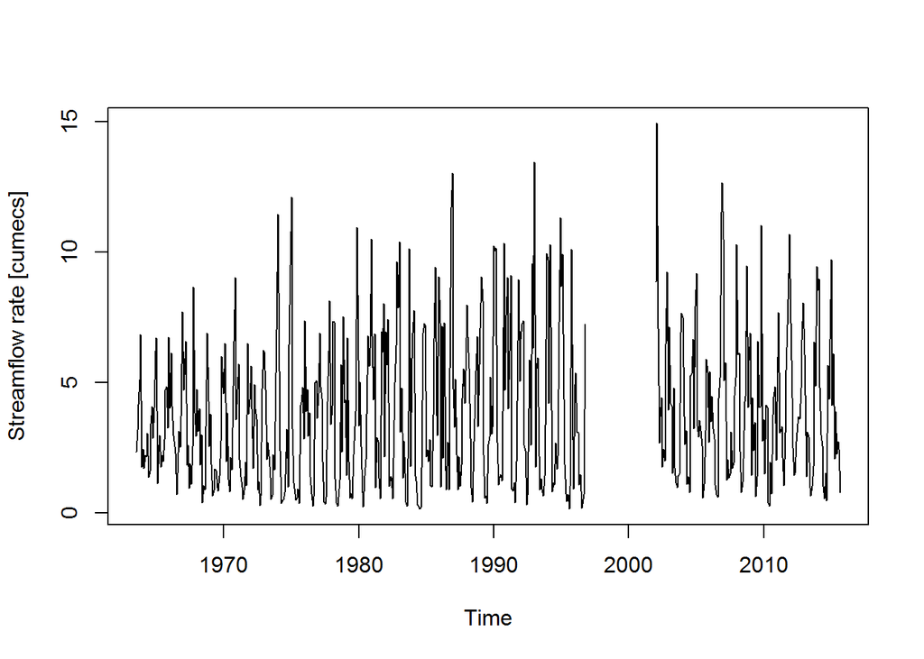

Gryfe River streamflow

```r
plot(Qts, ylab = "Streamflow rate [cumecs]")            # Plot data
```

```r
print(round(Qts,1))  # Display data (rounded to one decimal place)
```

```
##       Jan  Feb  Mar  Apr  May  Jun  Jul  Aug  Sep  Oct  Nov  Dec
## 1963                                2.3  3.2  4.2  5.1  6.9  1.7
## 1964  2.5  1.7  2.2  2.2  3.0  1.4  1.6  3.4  4.1  2.9  4.0  6.2
## 1965  6.7  1.1  2.6  3.0  1.8  2.2  2.0  2.8  4.7  4.8  3.3  6.7
## 1966  4.0  6.1  4.1  3.0  2.6  2.3  0.7  1.5  3.1  2.5  3.7  7.7
## 1967  4.7  5.3  6.6  1.9  2.6  0.9  1.9  1.1  2.6  8.7  3.8  2.9
## 1968  4.7  3.1  4.0  1.8  3.0  0.4  1.0  0.9  3.3  6.9  4.3  2.6
## 1969  3.8  1.9  0.6  0.9  1.7  1.6  1.0  0.8  1.4  2.8  6.0  4.8
## 1970  4.6  6.5  2.0  3.8  1.3  0.8  2.1  1.7  4.9  6.6  9.0  3.6
## 1971  4.7  5.7  2.0  1.4  1.0  0.5  0.9  1.9  1.1  6.5  3.8  4.3
## 1972  5.6  4.0  1.7  4.9  4.0  3.6  0.9  1.2  0.3  0.7  4.8  6.2
## 1973  6.2  4.7  2.0  2.7  2.2  1.4  0.5  0.7  2.2  1.7  5.4  7.0
## 1974 11.4  5.5  2.4  0.4  0.5  0.5  0.8  1.5  3.2  1.0  6.4  9.5
## 1975 12.1  3.2  1.2  0.7  0.5  0.6  0.9  0.4  4.1  4.2  4.8  2.8
## 1976  7.4  3.9  4.7  2.9  3.8  1.4  0.7  0.3  0.6  5.0  5.1  3.6
```

[output cut: 39 more lines]

Note that the plot automatically gives the time along the x-axis and that, when printed, the data are displayed as a matrix with months as column headers and years as row names. You can look at the data and quickly spot a number of important features. For example, there is a signicant gap in the record. As a hydrologist, you might look to establish the cause of missing data[^2] and whether there are rainfall records for the catchment that might enable allow you to *reconstruct* the record. It’s also clear from the consistent fluctuation of the series that the data are highly seasonal. If you want to take a closer look at the seasonal pattern, you can expand out the time series across a number of plots using the `xyplot.ts` function in the `lattice` package. First, install `lattice` by entering `install.packages("lattice")`. Then run the following code[^3]:

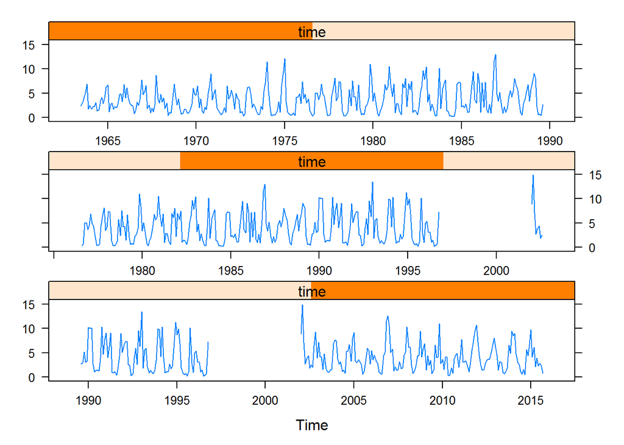

```r
lattice::xyplot.ts(Qts, cut = 3)
```

You can further examine seasonality in your time series using `monthplot`, which plots the individual series for each month:

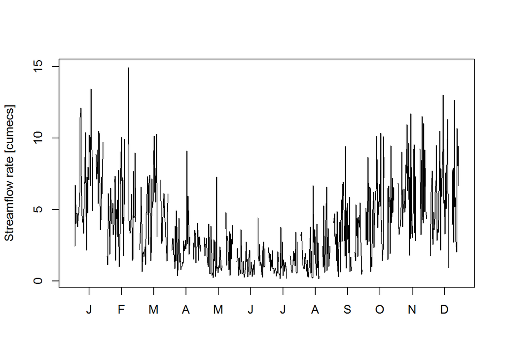

```r
monthplot(Qts, ylab = "Streamflow rate [cumecs]")
```

The strong seasonal pattern is clear from this plot. If you’re interested in whether there’s any discerable trend or shift in the time series, you can remove the seasonality. The easiest way to do this is to *aggregate* to mean annual flow rate:

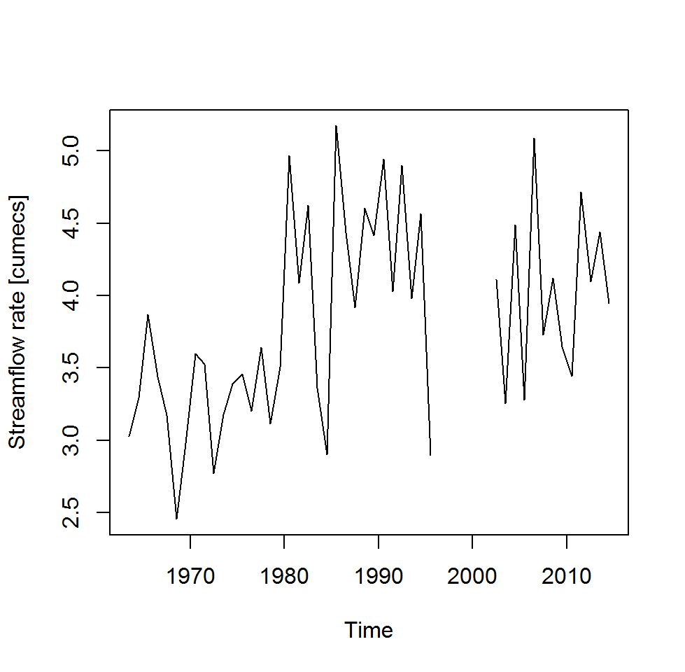

Gryfe River mean annual streamflow

```r
Qannual <- aggregate(Qts, FUN = mean)
plot(Qannual, ylab = "Streamflow rate [cumecs]")
```

```r
print(Qannual)
```

```
## Time Series:
## Start = 1963.5
## End = 2014.5
## Frequency = 1
##  [1] 3.027574 3.292144 3.866594 3.438822 3.171534 2.454932 2.980804
##  [8] 3.600087 3.526404 2.771770 3.177212 3.388841 3.457512 3.202161
## [15] 3.639125 3.115436 3.506438 4.966676 4.086790 4.622369 3.361728
## [22] 2.902597 5.173695 4.437428 3.916230 4.606688 4.414376 4.944638
## [29] 4.027231 4.897479 3.979639 4.564499 2.894393       NA       NA
## [36]       NA       NA       NA       NA 4.111853 3.255992 4.487088
## [43] 3.278829 5.089736 3.727779 4.119605 3.647981 3.441919 4.715108
## [50] 4.094348 4.437923 3.945965
```

The time series object `Qts` already has months and years programmed in—so the `aggregate` function assumes automatically that the data are to be aggregated from monthly to annual. By setting `FUN = mean` you tell the function to aggregate each year of data by taking the mean across all months in each year[^4].

## Step 3: Perform some quick statistical analysis

The data appear to exhibit a shift in the mean annual streamflow, occurring around 1980. You can use the `window` function to separate out the time series object for computing statistics relating to pre- and post- 1980:

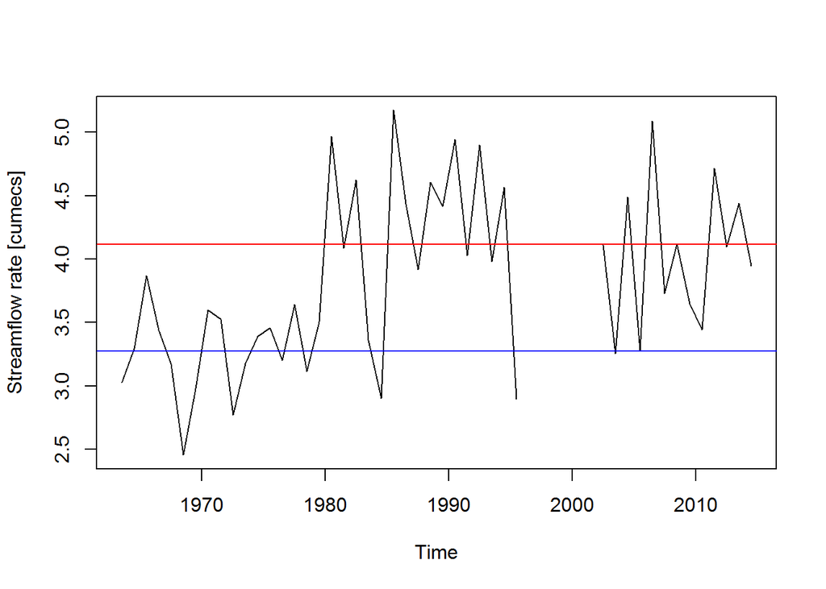

Gryfe River mean annual streamflow

```r
plot(Qannual, ylab = "Streamflow rate [cumecs]")
Qannual_pre1980 <- window(Qannual, end = 1980)
Qannual_post1980 <- window(Qannual, start = 1981)

# PLOT MEAN OF EACH PERIOD FOR COMPARISON
abline(h=mean(Qannual_pre1980), col = "blue")
abline(h=mean(Qannual_post1980, na.rm = TRUE), col = "red")
```

```r
mean(Qannual_pre1980)
```

```
## [1] 3.271611
```

```r
sd(Qannual_pre1980)
```

```
## [1] 0.3448535
```

```r
mean(Qannual_post1980, na.rm = TRUE)
```

```
## [1] 4.113711
```

```r
sd(Qannual_post1980, na.rm = TRUE)
```

```
## [1] 0.6309865
```

parameter na.rm was set to TRUE for calculating statistics for the post-1980 period. na.rm = TRUE instructs the function to *remove NA values* before computing the statistic. If we don’t remove the NA values (i.e., the missing part of the record), R won’t calculate the mean or the standard deviation!

The figures show that something probably happened around the year 1980 which has caused the mean and the variance of the streamflow to increase quite substantially. This particular record is impacted by a reservoir upstream, so with some further investigation you might be able to determine whether river regulation caused the apparent change. You could rule out climate factors by looking at rainfall for the catchment to see if a similar pattern emerges, for instance.

(to be continued…)

[^1]: For example, if you have hourly data, you can time-stamp it by assuming the unit of time is one day (`frequency = 24`). Alternatively, you could assume the unit of time is one week (`frequency = 168`), and so on.
[^2]: It turns out that the weir used for flow measurement collapsed in 1996 and wasn’t repaired till 2002
[^3]: Note that the use of `lattice::` before the function. The `::` term allows you to call functions from a package without actually loading the package into the project environment. Alternatively you can just load the package by entering `require(lattice)` and then running the function as normal using `xpplot.ts(Qts, cut = 3)`.
[^4]: We can substitute `mean` for `max`, `min`, `sum`, or indeed any function that can be applied to the data.